# **ERROS PENDENTES DE CORREÇÃO**

#### Especificação - Dados da Consulta

(inicio)

Esse documento tem como base a criação de uma nova consulta para possibilitar o acompanhamento das ações desenvolvidas pelo governo do estado com recursos provenientes do acordo judicial firmado com a Vale .

#### Pesquisa Básica - Tipo de Consultas

(inicio)

Para acessar o comportamento padrão da consulta básica acesse a [Especificação Layout - Consulta Básica](https://github.com/transparencia-mg/especificacoes-portal-transparencia/blob/espec018_recusos-vale/espec018_recursos-acordo-judicial-vale/recursos-vale-espec.md)

#### Por Projeto

(inicio)

Os dados dessa consulta serão extraídos do Universo BO SIGCON- Entrada. - Armazém BO / Pastas públicas - SIAFI > SUPORTE- SIAFI > CGE > Consulta Vale Recursos Vale> Tela Projeto

#### Filtros da Consulta

Essa consulta será plurianual, ou seja, o usuário irá visualizar todos os projetos e valores independente do ano.

| Fonte de Dados | URL |
| --- | --- |
| Portal de Dados Abertos | https://homologa.cge.mg.gov.br/dataset/projetos-acordo-judicial-reparacao-vale |

Nota: Ess url será utilizada apenas para fins de testes.

#### Campos da Tabela

| Portal de Dados Abertos | PdT | Tooltip - PdT | Exibição da Coluna |
| --- | --- | --- | --- |
| Código Projeto | Código Projeto | Código do Projeto no armazém SIAFI (Sistema Integrado de Administração Financeira de Minas Gerais ) | default |
| Projeto | Projeto | Descrição do Projeto conforme consta no Acordo de Reparação e de execução do Governo do Estado | default |
| Anexo | Anexo | Anexo ao qual o Projeto se refere conforme o Acordo de Reparação | default |
| Valor do Projeto | Valor do Projeto | Valor total destinado ao projeto | default |

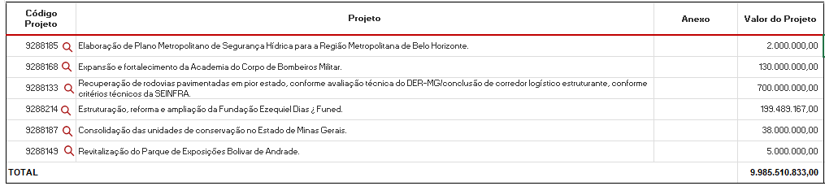

**Comportamento da Consulta:**

- Ao clicar no campo ‘Código Projeto’ o usuário será direcionado para o 2º nível da consulta por execução, ou seja, a tabela de empenhos **com o acréscimo das colunas Código Órgão e Órgão**. A consulta deverá exibir todos dos empenhos relacionados ao Código Projeto selecionado independentemente do ano de registro do empenho.

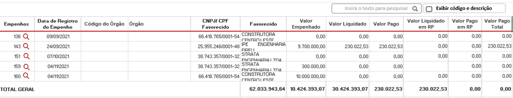

#### Por Execução

(inicio)

Os dados dessa consulta serão extraídos do Universo BO SIAFI - Armazém BO / Pastas públicas - SIAFI > SUPORTE- SIAFI > CGE > Consulta Vale Recursos Vale> TELA ÓRGÃO

#### Filtros da Consulta

Essa consulta será anual, ou seja, o usuário irá visualizar a execução (Despesa e restos a Pagar) do projeto conforme o período selecionado.

| Dados | Armazém BO- SIAFI | Dimensão SIAFI | Filtro |
| --- | --- | --- | --- |
| Despesa | Contrato Convênio Entrada | SIAFI - Execução Orçamentária da Despesa > Despesa Realizada | Usar como filtro todos os ‘Códigos Projeto’ listados na consulta Por Projeto |
| Restos a Pagar | Contrato Convênio Entrada | SIAFI - Execução de Restos a Pagar > Restos a Pagar | Usar como filtro todos os ‘Códigos Projeto’ listados na consulta Por Projeto |
|  | Ano de Exercício | SIAFI - Período Contábil |  |

#### Campos da Tabela

##### Tabela 1º nível

| Dados | Campo armazém BO- SIAFI | Dimensão SIAFI | Campo PdT | Tooltip - PdT | Exibição da Coluna |
| --- | --- | --- | --- | --- | --- |
| Despesa | ContratoConvênio Entrada | SIAFI - Execução Orçamentária da Despesa > Despesa Realizada | Código Projeto | Código do Projeto no armazém SIAFI (Sistema Integrado de Administração Financeira de Minas Gerais ) | default |
| Despesa | Unidade Orçamentária-Código | SIAFI - Execução Orçamentária da Despesa > Despesa Realizada | Código Órgão | Código da Unidade Orçamentária responsável pelo Projeto | ao acionar o botão ‘*Exibir código e descrição*’’ |
| Despesa | Unidade Orçamentária-Nome | SIAFI - Execução Orçamentária da Despesa > Despesa Realizada | Órgão | Descrição da Unidade Orçamentária responsável pelo Projeto | default |
| Despesa | Valor Despesa Empenhada | SIAFI - Execução Orçamentária da Despesa > Despesa Realizada | Valor Empenhado | Valor do orçamento reservado para cumprir o compromisso assumido com o fornecedor ou credor | default |
| Despesa | Valor Despesa Liquidada | SIAFI - Execução Orçamentária da Despesa > Despesa Realizada | Valor Liquidado | Valor que o fornecedor ou credor tem direito a receber referente ao produto ou serviço devidamente entregue | default |
| Despesa | Valor Pago Financeiro | SIAFI - Execução Orçamentária da Despesa > Despesa Realizada | Valor Pago | Valor referente aos pagamentos efetuados, no exercício, através de movimentações bancárias, escriturais e apropriação contábil da despesa. O efetivo pagamento pode estar pendente de transmissão bancár… | default |
| Restos a Pagar | Valor Despesa Liquidada | SIAFI - Execução de Restos a Pagar > Restos a Pagar | Valor Liquidado em RP | Valor que o fornecedor ou credor tem direito a receber referente ao produto ou serviço devidamente entregue referente a exercícios anteriores | default |
| Restos a Pagar | -Valor Pago Processado -Valor Pago não processado | SIAFI - Execução de Restos a Pagar > Restos a Pagar | Valor Pago em Restos a Pagar | Valor pago referente a exercícios anteriores efetuados através de movimentações bancárias, escriturais e apropriação contábil da despesa, referente a produtos e serviços realizados em exercícios anter… | default |
| Fórmula Portal |  |  | Valor Total Pago | Somatório dos valores pagos neste exercício e pagos em restos a pagar processados e não processados. | default |

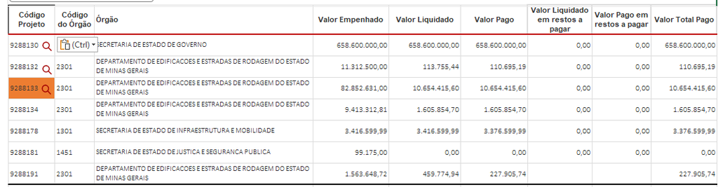

**Comportamento da Consulta:**

- Ao clicar no campo ‘Código Projeto’ o usuário será direcionado para o 2º nível da consulta, ou seja, tabela de empenhos. ____

##### Tabela 2º nível

- Armazém BO / Pastas públicas - SIAFI > SUPORTE- SIAFI > CGE > Consulta Vale Recursos Vale> TELA ÓRGÃO - nível 2

Ao clicar em algum dado do campo ‘Código Projeto’ o usuário será direciona ao segundo nível da consulta, lista de empenhos correspondente ao código Projeto selecionado.

| Dados | Campo Armazém BO- SIAFI | Dimensão SIAFI | Campo PdT | Tooltip - PdT | Exibição da Coluna |
| --- | --- | --- | --- | --- | --- |
| Despesa | Número Empenho | SIAFI - Execução Orçamentária da Despesa > Despesa Realizada | Empenho | Número de identificação do documento de empenho no SIAFI (Sistema Integrado de Administração Financeira de Minas Gerais ) | default |
| Despesa | Data Registro Doc Empenho | SIAFI - Execução Orçamentária da Despesa > Despesa Realizada | Data de Registro do Empenho | Data de registro do documento de empenho | default |
| Despesa | CNPJ_CPF Credor - Formatado | SIAFI - Execução Orçamentária da Despesa > Despesa Realizada | CNPJ/ CPF Favorecido | Número de identificação: Pessoa Física (CPF) e Pessoa Jurídica (CNPJ) | default |
| Despesa | Razão Social Credor | SIAFI - Execução Orçamentária da Despesa > Despesa Realizada | Favorecido | Nome de quem recebeu recursos públicos estaduais pela prestação de serviço ou entrega do produto. Ex: prefeituras, servidores, empresas, entidades do terceiro setor, etc. | default |
| Despesa | Valor Despesa Empenhada | SIAFI - Execução Orçamentária da Despesa > Despesa Realizada | Valor Empenhado | Valor do orçamento reservado para cumprir o compromisso assumido com o fornecedor ou credor | default |
| Despesa | Valor Despesa Liquidada | SIAFI - Execução Orçamentária da Despesa > Despesa Realizada | Valor Liquidado | Valor que o fornecedor ou credor tem direito a receber referente ao produto ou serviço devidamente entregue | default |
| Despesa | Valor Pago Financeiro | SIAFI - Execução Orçamentária da Despesa > Despesa Realizada | Valor Pago | Valor referente aos pagamentos efetuados, no exercício, através de movimentações bancárias, escriturais e apropriação contábil da despesa. O efetivo pagamento pode estar pendente de transmissão bancár… | default |
| Restos a Pagar | Valor Despesa Liquidada | SIAFI - Execução de Restos a Pagar > Restos a Pagar | Valor Liquidado em RP | Valor que o fornecedor ou credor tem direito a receber referente ao produto ou serviço devidamente entregue referente a exercícios anteriores | default |
| Restos a Pagar | - Valor Pago Processado - Valor Pago não processado | SIAFI - Execução de Restos a Pagar > Restos a Pagar | Valor Pago em Restos a Pagar | Valor pago referente a exercícios anteriores efetuados através de movimentações bancárias, escriturais e apropriação contábil da despesa, referente a produtos e serviços realizados em exercícios anter… | default |
| Fórmula Portal |  |  | Valor Total Pago | Somatório dos valores pagos neste exercício e pagos em restos a pagar processados e não processados. | default |

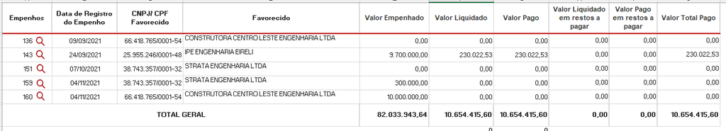

**Comportamento da Consulta:**

- Ao clicar no campo ‘Empenho’ o usuário será direcionado o formulário de detalhamento.

##### Formulário de Detalhamento

- Armazém BO / Pastas públicas - SIAFI > SUPORTE- SIAFI > CGE > Consulta Vale Recursos Vale> > Formulário de Detalhamento

O formulário de detalhamento deverá exibir a inscrição, liquidação e pagamento dos valores em restos a pagar referente ao todos os exercícios. Exemplo: - Ano de registro do Empenho: 2020 - Inscrição em Restos a Pagar: 2021 - Reinscrito em Restos e Pagar: 2022

**1- Formulário Classificação Orçamentária**

| Dados | Campo Armazém BO- SIAFI | Dimensão SIAFI | Campo PdT | Observações |
| --- | --- | --- | --- | --- |
| Despesa | Número Empenho | SIAFI - Execução Orçamentária da Despesa > Despesa Realizada | Empenho |  |
| Despesa | Data Registro Doc Empenho | SIAFI - Execução Orçamentária da Despesa > Despesa Realizada | Data de Registro |  |
| Despesa | Unidade Orçamentária - Código/Nome | SIAFI - Unidade Orçamentária | Unidade Orçamentária | Código e descrição no mesmo campo |
| Despesa | Unidade Executora - Código/Nome | SIAFI - Unidade Executora | Unidade Executora | Código e descrição no mesmo campo |
| Despesa | Função - Descrição | SIAFI - Execução Orçamentária da Despesa > Despesa Realizada > Programa de Trabalho - Despesa | Função | Código e descrição no mesmo campo |
| Despesa | Função - Código | SIAFI - Execução Orçamentária da Despesa > Despesa Realizada > Programa de Trabalho - Despesa |  | Código e descrição no mesmo campo |
| Despesa | Subfunção - Descrição | SIAFI - Execução Orçamentária da Despesa > Despesa Realizada > Programa de Trabalho - Despesa | Subfunção | Código e descrição no mesmo campo |
| Despesa | Subfunção - Código | SIAFI - Execução Orçamentária da Despesa > Despesa Realizada > Programa de Trabalho - Despesa |  | Código e descrição no mesmo campo |
| Despesa | Programa - Descrição | SIAFI - Execução Orçamentária da Despesa > Despesa Realizada > Programa de Trabalho - Despesa | Programa | Código e descrição no mesmo campo |
| Despesa | Programa - Código | SIAFI - Execução Orçamentária da Despesa > Despesa Realizada > Programa de Trabalho - Despesa |  | Código e descrição no mesmo campo |
| Despesa | Projeto_Atividade - Descrição | SIAFI - Execução Orçamentária da Despesa > Despesa Realizada > Programa de Trabalho - Despesa | Ação (Projeto Atividade) | Código e descrição no mesmo campo |
| Despesa | Projeto_Atividade - Código | SIAFI - Execução Orçamentária da Despesa > Despesa Realizada > Programa de Trabalho - Despesa |  | Código e descrição no mesmo campo |
| Despesa | Categoria Econômica Despesa - Desc | SIAFI - Execução Orçamentária da Despesa > Despesa Realizada > Natureza da Despesa Realizada | Categoria Econômica da Despesa | Código e descrição no mesmo campo |
| Despesa | Categoria Econômica Despesa - Código | SIAFI - Execução Orçamentária da Despesa > Despesa Realizada > Natureza da Despesa Realizada |  | Código e descrição no mesmo campo |
| Despesa | Grupo Despesa - Descrição | SIAFI - Execução Orçamentária da Despesa > Despesa Realizada > Natureza da Despesa Realizada | Grupo de Despesa | Código e descrição no mesmo campo |
| Despesa | Grupo Despesa - Código | SIAFI - Execução Orçamentária da Despesa > Despesa Realizada > Natureza da Despesa Realizada |  | Código e descrição no mesmo campo |
| Despesa | Modalidade de Aplicação - Descrição | SIAFI - Execução Orçamentária da Despesa > Despesa Realizada > Natureza da Despesa Realizada | Modalidade de Aplicação | Código e descrição no mesmo campo |
| Despesa | Modalidade de Aplicação - Código | SIAFI - Execução Orçamentária da Despesa > Despesa Realizada > Natureza da Despesa Realizada |  | Código e descrição no mesmo campo |
| Despesa | Elemento Despesa - Descrição | SIAFI - Execução Orçamentária da Despesa > Despesa Realizada > Natureza da Despesa Realizada | Elemento de Despesa | Código e descrição no mesmo campo |
| Despesa | Elemento Despesa - Código | SIAFI - Execução Orçamentária da Despesa > Despesa Realizada > Natureza da Despesa Realizada |  | Código e descrição no mesmo campo |
| Despesa | Item Despesa - Descrição | SIAFI - Execução Orçamentária da Despesa > Despesa Realizada > Natureza da Despesa Realizada | Item de Despesa | Código e descrição no mesmo campo |
| Despesa | Item Despesa - Código | SIAFI - Execução Orçamentária da Despesa > Despesa Realizada > Natureza da Despesa Realizada |  | Código e descrição no mesmo campo |
| Despesa | Fonte Recurso - Descrição | SIAFI - Execução Orçamentária da Despesa > Despesa Realizada > GMIFP | Fonte de Recurso | Código e descrição no mesmo campo |
| Despesa | Fonte Recurso - Código | SIAFI - Execução Orçamentária da Despesa > Despesa Realizada > GMIFP |  | Código e descrição no mesmo campo |
| Despesa | Procedência - Descrição | SIAFI - Execução Orçamentária da Despesa > Despesa Realizada > GMIFP | Indicador de Procedência e Uso (IPU) | Código e descrição no mesmo campo |
| Despesa | Procedência - Código | SIAFI - Execução Orçamentária da Despesa > Despesa Realizada > GMIFP |  | Código e descrição no mesmo campo |

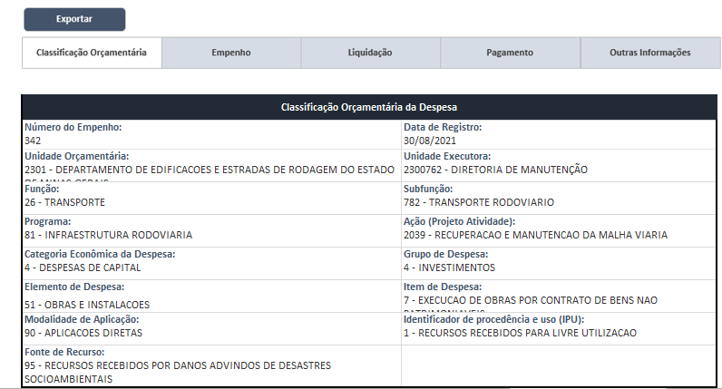

**2- Formulário Empenho**

| Dados | Campo Armazém BO- SIAFI | Dimensão SIAFI | Campo PdT | Observações |
| --- | --- | --- | --- | --- |
| Detalhamento do Empenho | Número Empenho | SIAFI - Execução Orçamentária da Despesa > Despesa Realizada | Empenho |  |
| Detalhamento do Empenho | Data Registro Doc Empenho | SIAFI - Execução Orçamentária da Despesa > Despesa Realizada | Data de Registro |  |
| Detalhamento do Empenho | Ano de Exercício | SIAFI - Período Contábil | Ano de Exercício |  |
| Despesa | Tipo Empenho - Descrição | SIAFI - Execução Orçamentária da Despesa > Despesa Realizada | Tipo de Empenho |  |
| Detalhamento do Empenho | CNPJ_CPF Credor - Formatado | SIAFI - Execução Orçamentária da Despesa > Despesa Realizada |  | Código e descrição no mesmo campo |
| Detalhamento do Empenho | Razão Social Credor | SIAFI - Execução Orçamentária da Despesa > Despesa Realizada | CNPJ/ CPF e Descrição do Favorecido | Código e descrição no mesmo campo |
| Detalhamento do Empenho | Valor Inicial Empenho | SIAFI - Execução Orçamentária da Despesa > Despesa Realizada | Valor inicial empenhado |  |
| Detalhamento do Empenho | Valor Despesa Empenhada | SIAFI - Execução Orçamentária da Despesa > Despesa Realizada | Valor atual do empenho (reforços e anulações) |  |
| Detalhamento do Empenho |  |  | Descrição Histórico do Empenho | Integração entre Portal e SIAFI |
| Reforço do Empenho | Valor Reforço Empenho | SIAFI - Execução Orçamentária da Despesa > Despesa Realizada | Valor |  |
| Reforço do Empenho |  | SIAFI - Execução Orçamentária da Despesa > Despesa Realizada | Nº do documento | Campo SIAFI não disponível para visualização da DTA. Trazer o campo já utilizado no formulário de detalhamento da despesa |
| Reforço do Empenho | Data Reforço/Anulação | SIAFI - Execução Orçamentária da Despesa > Despesa Realizada | Data de Registro |  |
| Anulação do Empenho | Valor Anulação Empenho | SIAFI - Execução Orçamentária da Despesa > Despesa Realizada | Valor |  |
| Anulação do Empenho |  | SIAFI - Execução Orçamentária da Despesa > Despesa Realizada | Nº do documento | Campo SIAFI não disponível para visualização da DTA. Trazer o campo já utilizado no formulário de detalhamento da despesa. |
| Anulação do Empenho | Data Reforço/Anulação | SIAFI - Execução Orçamentária da Despesa > Despesa Realizada | Data de Registro |  |
| Inscrição em Restos a Pagar | Data Registro Doc Empenho | SIAFI - Execução de Restos a Pagar > Restos a Pagar > Dados do Empenho - Restos a Pagar | Data de Registro | Data de registro que o empenho foi inscrito em Restos a Pagar |
| Inscrição em Restos a Pagar |  |  | Tipo de Inscrição | Campo SIAFI não disponível para visualização da DTA. Trazer o campo já utilizado no formulário de detalhamento da consulta de Restos a pagar |
| Inscrição em Restos a Pagar | **soma** do Valor Inscrito Processado - Valor Cancelado Processado ou Valor Restabelecido Processado **OU soma** do Valor Inscrito Não Processado - Valor Cancelado Não Processado + Valor Restabelecido… | SIAFI - Execução de Restos a Pagar > Restos a Pagar | Valor Inscrito | Cada linha deverá apresentar o valor corresponde ao tipo de inscrição em restos a pagar. |

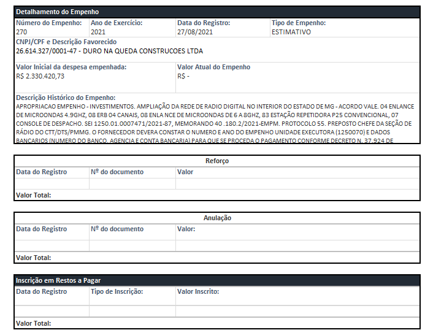

**3- Formulário Liquidação**

| Dados | Campo Armazém BO- SIAFI | Dimensão SIAFI | Campo PdT | Observações |
| --- | --- | --- | --- | --- |
| Detalhamento da Liquidação |  | SIAFI - Execução Orçamentária da Despesa > Despesa Realizada | Nº do documento | Campo SIAFI não disponível para visualização da DTA. Trazer o campo já utilizado no formulário de detalhamento da liquidação. |
| Detalhamento da Liquidação | Data Registro Doc Liquidação | SIAFI - Execução Orçamentária da Despesa > Despesa Realizada | Data de Registro |  |
| Detalhamento da Liquidação | CNPJ_CPF Credor - Formatado | SIAFI - Execução Orçamentária da Despesa > Despesa Realizada |  | Código e descrição no mesmo campo |
| Detalhamento da Liquidação | Razão Social Credor | SIAFI - Execução Orçamentária da Despesa > Despesa Realizada | CNPJ/ CPF e Descrição do Favorecido | Código e descrição no mesmo campo |
| Detalhamento da Liquidação | Valor Despesa Liquidada | SIAFI - Execução Orçamentária da Despesa > Despesa Realizada | Valor Liquidado |  |
| Liquidação em Restos a Pagar | Data Registro Doc Liquidação | SIAFI - Execução de Restos a Pagar > Restos a Pagar > Dados da Liquidação - Restos a Pagar | Data de Registro | Data de registro que o restos a pagar não processado foi liquidado. |
| Liquidação em Restos a Pagar | CNPJ_CPF Credor - Numérico | SIAFI - Execução de Restos a Pagar > Restos a Pagar |  | Código e descrição no mesmo campo |
| Liquidação em Restos a Pagar | Razão Social Credor | SIAFI - Execução de Restos a Pagar > Restos a Pagar | CNPJ/ CPF e Descrição do Favorecido | Código e descrição no mesmo campo |
| Liquidação em Restos a Pagar | Valor Despesa Liquidada | SIAFI - Execução de Restos a Pagar > Restos a Pagar | Valor Liquidado RP | Valor liquidado do restos a pagar não processado |

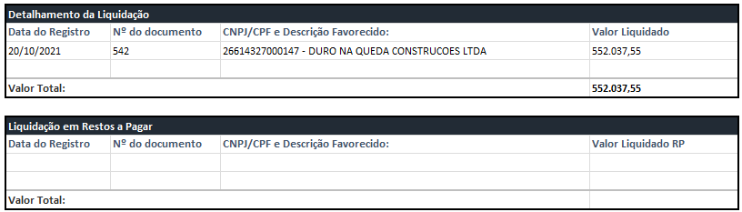

**4- Formulário Pagamento**

| Dados | Campo Armazém BO- SIAFI | Dimensão SIAFI | Campo PdT | Observações |
| --- | --- | --- | --- | --- |
| Detalhamento do Pagamento | Data de Registro | SIAFI - Execução Orçamentária da Despesa > Despesa Realizada > Dados da Ordem de Pagamento - Despesa | Data de Registro do pagamento |  |
| Detalhamento do Pagamento | Número Docto Pagamento | SIAFI - Execução Orçamentária da Despesa > Despesa Realizada > Dados da Ordem de Pagamento - Despesa | Nº do documento |  |
| Detalhamento do Pagamento | Situação Ordem de Pagamento - Descrição | SIAFI - Execução Orçamentária da Despesa > Despesa Realizada > Dados da Ordem de Pagamento - Despesa | Situação da Ordem de Pagamento |  |
| Detalhamento do Pagamento | CNPJ_CPF Credor - Formatado | SIAFI - Execução Orçamentária da Despesa > Despesa Realizada |  | Código e descrição no mesmo campo |
| Detalhamento do Pagamento | Razão Social Credor | SIAFI - Execução Orçamentária da Despesa > Despesa Realizada | CNPJ/ CPF e Descrição do Favorecido | Código e descrição no mesmo campo |
| Detalhamento do Pagamento | Valor Pago Financeiro | SIAFI - Execução Orçamentária da Despesa > Despesa Realizada | Valor Pago |  |
| Pagamento em Restos a Pagar | Data Registro | SIAFI - Execução de Restos a Pagar > Restos a Pagar > Dados da Ordem de Pagamento - Restos a Pagar | Data de Registro do pagamento | Data de registro que o restos a pagar foi pago. |
| Pagamento em Restos a Pagar | Número Ordem de Pagamento | SIAFI - Execução de Restos a Pagar > Restos a Pagar > Dados da Ordem de Pagamento - Restos a Pagar | Nº do documento |  |
| Detalhamento do Pagamento | Situação Ordem de Pagamento - Descrição | SIAFI - Execução de Restos a Pagar > Restos a Pagar > Dados da Ordem de Pagamento - Restos a Pagar | Situação da Ordem de Pagamento |  |
| Pagamento em Restos a Pagar | CNPJ_CPF Credor - Numérico | SIAFI - Execução de Restos a Pagar > Restos a Pagar |  | Código e descrição no mesmo campo |
| Pagamento em Restos a Pagar | Razão Social Credor | SIAFI - Execução de Restos a Pagar > Restos a Pagar | CNPJ/ CPF e Descrição do Favorecido | Código e descrição no mesmo campo |
| Pagamento em Restos a Pagar | Valor Pago Processado ou Valor Pago não processado | SIAFI - Execução de Restos a Pagar > Restos a Pagar | Valor Pago em RP |  |

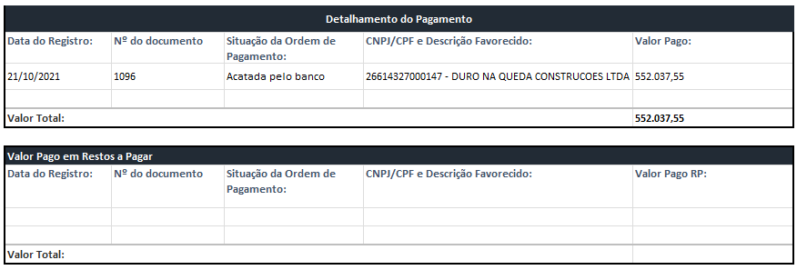

**4- Formulário Outras Informações**

| Dados | Campo Armazém BO | Dimensão Armazém BO | Campo PdT | Observações |
| --- | --- | --- | --- | --- |
| Dados do Processo de Compra | Número do Processo de Compra | SIAFI - Execução Orçamentária da Despesa > Despesa Realizada | Número do Processo de Compra | Campo utilizado para cruzamento das informações empenho vs processo de compra. Ao identificar qual processo de compra está vinculado ao empenho os demais dados referente ao processo serão extraídos do… |
| Dados do Processo de Compra | Data criação do Processo | Armazém SIADI - Portal de Compras - Módulo Compras > Data criação do Processo | Data de Cadastramento do Processo |  |
| Dados do Processo de Compra | Procedimento de Contratação - Detalhamento 1 | Armazém SIADI - Portal de Compras - Módulo Compras > Procedimento de Contratação | Procedimento de Contratação |  |
| Dados do Processo de Compra | Situação Processo | Armazém SIADI - Portal de Compras - Módulo Compras | Situação do Processo |  |
| Dados do Processo de Compra | Objeto Processo | Armazém SIADI - Portal de Compras - Módulo Compras | Objeto do Processo |  |
| Dados Contrato | Número Contrato | Armazém SIADI - Portal de Compras - Módulo Compras > Contrato | Número do Contrato |  |
| Dados Contrato | Data Publicação Contrato | Armazém SIADI - Portal de Compras - Módulo Compras > Data Publicação Contrato | Data de Publicação |  |
| Dados Contrato | Data Término Vigência Contrato | Armazém SIADI - Portal de Compras - Módulo Compras > Data Atualizada Término Vigência Contrato | Vigência atualizada |  |
| Dados Contrato | Situação Contrato | Armazém SIADI - Portal de Compras - Módulo Compras > Contrato | Situação do Contrato |  |
| Dados Contrato | Objeto Contrato | Armazém SIADI - Portal de Compras - Módulo Compras > Contrato | Objeto do Contrato |  |
| Dados do Convênio / Parceria de Saída Recursos | Contrato Convênio Saída | SIAFI - Execução Orçamentária da Despesa > Despesa Realizada > Dados do Empenho - Despesa | Número do Convênio / Parceria SIAFI | Ao identificar que existe ‘Contrato Convênio Saída’ relacionado a um empenho deve-se realizar o cruzamento com a base de dados do Pdt consulta Convênio de Saída / Parceria de recursos e caso a informa… |
| Dados do Convênio/Parceria de Saída Recursos | Data Publicação | PdT - Consulta Convênios / Parceria de Saída de Recursos | Data de Publicação |  |
| Dados do Convênio/Parceria de Saída Recursos | Vigência atualizada | PdT - Consulta Convênios / Parceria de Saída de Recursos | Vigência atualizada |  |
| Dados do Convênio/Parceria de Saída Recursos | Situação do Convênio / Parceria | PdT - Consulta Convênios / Parceria de Saída de Recursos | Situação do Convênio / Parceria |  |
| Dados do Convênio/Parceria de Saída Recursos | Título do Convênio / Parceria | PdT - Consulta Convênios / Parceria de Saída de Recursos | Título do Convênio / Parceria |  |

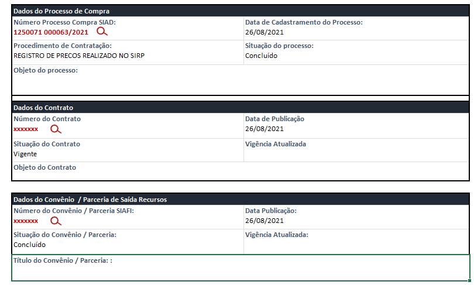

**Comportamento da Consulta:**

- Ao clicar no campo ‘Número do Processo de Compra’ o usuário será direcionado o formulário de detalhamento da consulta [Compras e Contratos](https://www.transparencia.mg.gov.br/compras-e-patrimonio/compras-e-contratos/comprasecontratos-detalhe-proccompra/2021/20210101/20211231/352133).
- Ao clicar no campo ‘Número do Contrato’ o usuário poderá fazer o [download do contrato](https://www1.compras.mg.gov.br/contrato/gestaocontratos/arquivosContrato.html?idContrato=170153).
- Ao clicar no campo ‘Número do Convênio / Parceria SIAFI’ o usuário será direcionado o formulário de detalhamento da consulta [Consulta Convênios / Parceria de Saída de Recursos](https://www.transparencia.mg.gov.br/convenios/convenios-de-saida/convenios-conslivre-detalhesconv/2021/01-01-2021/31-12-2021/61691)

#### Por Município

(inicio)

Os dados dessa consulta serão extraídos do Universo BO SIAFI. - Armazém BO / Pastas públicas - SIAFI > SUPORTE- SIAFI > CGE > Consulta Vale Recursos Vale> Tela Município

#### Filtros da Consulta

Essa consulta será plurianual, ou seja, o usuário irá visualizar todos repasses referente ao Município independentemente do ano de repasse.

| Armazém BO- SIAFI | Filtro |
| --- | --- |
| Contrato Convênio Entrada | 9288130 |

#### Campos da Tabela

| Dados | Campo armazém BO- SIAFI | Dimensão SIAFI | Campo PdT | Tooltip - PdT | Exibição da Coluna |
| --- | --- | --- | --- | --- | --- |
| Município | Ano de Exercício | Período Contábil | Ano do Repasse | Ano de exercício que o repasse ocorreu | — |
| Município | Município Credor - Descrição | SIAFI - Execução Orçamentária da Despesa - Despesa Realizada > Credor - Despesa | Município | Nome do Município que recebeu os repasses do Acordo Judicial conforme art. 5º e anexo V da Lei Estadual nº 23.830/2021 | *default* |
| Município | Número Empenho | SIAFI - Execução Orçamentária da Despesa - Despesa Realizada | Empenho | Número de identificação do documento de empenho no SIAFI (Sistema Integrado de Administração Financeira de Minas Gerais ) | *default* |
| Município | Data Registro | SIAFI - Execução Orçamentária da Despesa > Despesa Realizada > Dados da Ordem de Pagamento - Despesa | Data de Registro do pagamento | Data de Registro do Pagamento no SIAFI (Sistema Integrado de Administração Financeira de Minas Gerais ) | *default* |
| Município | Situação Ordem de Pagamento - Descrição | SIAFI - Execução Orçamentária da Despesa > Despesa Realizada > Dados da Ordem de Pagamento - Despesa | Situação da Ordem de Pagamento | Situação da Ordem de Pagamento conforme consta no SIAFI (Sistema Integrado de Administração Financeira de Minas Gerais ) | *default* |
| Município | Valor Pago Financeiro | SIAFI - Execução Orçamentária da Despesa > Despesa Realizada | Valor Pago | Valor referente aos repasses efetuados conforme art. 5º e anexo V da Lei Estadual nº 23.830/2021 do Acordo Judicial | *default* |

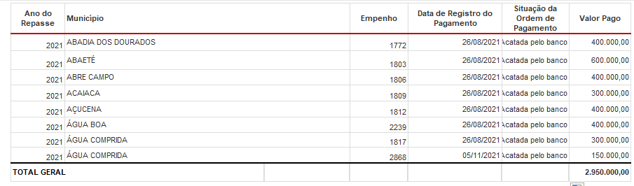

**Comportamento da Consulta:**

- Ao clicar no campo ‘Empenho’ o usuário será direcionado o formulário de detalhamento referente ao empenho.

#### Por Receita

(inicio)

Os dados dessa consulta serão extraídos do Universo BO SIAFI. - Armazém BO / Pastas públicas - SIAFI > SUPORTE- SIAFI > CGE > Consulta Vale Recursos Vale> Tela Receita

#### Filtros da Consulta

Essa consulta será plurianual, ou seja, o usuário irá visualizar os valores arrecadados por ano.

| Armazém BO- SIAFI | Filtro |
| --- | --- |
| Fonte de Recurso | 95 |
| Classificação Receita - Formatado | 2990.00.1.1.02.000 1990.99.1.1.10.000 |

#### Campos da Tabela

| Dados | Campo armazém BO- SIAFI | Dimensão SIAFI | Campo PdT | Tooltip - PdT | Exibição da Coluna |
| --- | --- | --- | --- | --- | --- |
| Receita | Ano de Exercício | SIAFI - Período Contábil | Ano de Exercício | Ano de exercício que ocorreu a arrecadação | *default* |
| Receita | Classificação Receita - Formatado | SIAFI - Execução Orçamentária da Receita > Receita Orçamentária > Classificação Receita Orçamentária a partir de 2018 > | Código da Classificação Receita | Classificação criada a fim de possibilitar a identificação detalhada dos recursos que ingressam nos cofres públicos. Os números representam, da esquerda para a direita: categoria econômica; origem da … | ao acionar o botão ‘Exibir código e descrição’ |
| Receita | Classificação Receita - Descrição | SIAFI - Execução Orçamentária da Receita > Receita Orçamentária > Classificação Receita Orçamentária a partir de 2018 | Classificação Receita | Descrição da identificação detalhada dos recursos que ingressam nos cofres públicos | *default* |
| Receita | Fonte de Recurso - Código | SIAFI - Execução Orçamentária da Receita > Receita Orçamentária > Classificação Receita Orçamentária a partir de 2018 | Código da Fonte de Recurso |  | ao acionar o botão ‘Exibir código e descrição’ |
| Receita | Fonte de Recurso - | SIAFI - Execução Orçamentária da Receita > Receita Orçamentária > Classificação Receita Orçamentária a partir de 2018 | Fonte de Recurso | Indica a origem do dinheiro arrecadado. Combina a origem do dinheiro às despesas orçamentárias. Esta vinculação visa demonstrar o montante de dinheiro que já está comprometido com o atendimento de det… | *default* |
| Receita | Valor Previsto Inicial | SIAFI - Execução Orçamentária da Receita > Receita Orçamentária > Classificação Receita Orçamentária a partir de 2018 | Valor Previsto Inicial | Valor estimado da arrecadação para o ano consultado, previsto na Lei Orçamentária Anual (LOA) | *default* |
| Receita | Valor Previsto Atualizado | SIAFI - Execução Orçamentária da Receita > Receita Orçamentária > Classificação Receita Orçamentária a partir de 2018 | Valor Previsto Atualizado | Valor estimado inicial para arrecadação no ano consultado, previsto na Lei Orçamentária Anual, atualizado ao longo do ano. | *default* |
| Receita | Valor Efetivado Ajustado | SIAFI - Execução Orçamentária da Receita > Receita Orçamentária > Classificação Receita Orçamentária a partir de 2018 | Valor Arrecadado | Valor financeiro que entrou nos cofres públicos no período consultado | *default* |

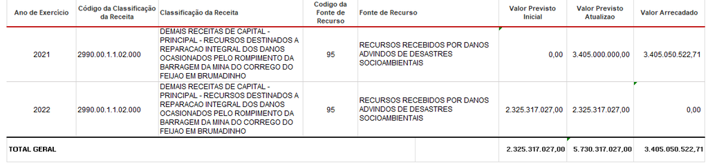

#### Monte sua pesquisa - Pesquisa Avançada

(inicio)

Os dados/tabelas da pesquisa avançada serão os mesmos que constam nas tabelas da pesquisa básica, porém será necessário verificar a granularidade para os devidos cruzamentos.

| Campo PdT | Barra vertical | Campos Adicionar/remover colunas |
| --- | --- | --- |
| Período *(Data)* | sim | *NÃO* |
| Período *(Apenas o ano)* | *NÃO* | sim |
| Código Projeto | sim | sim |
| Anexo | sim | **NÃO** |
| Projeto | sim | sim |
| Órgão | sim | sim |
| Unidade Executora | sim | sim |
| Função | sim | sim |
| Subfunção | sim | sim |
| Programa | sim | sim |
| Ação | sim | sim |
| Categoria Econômica da Despesa | sim | sim |
| Grupo de Despesa | sim | sim |
| Modalidade de Aplicação | sim | sim |
| Elemento de Despesa | sim | sim |
| Item de Despesa | sim | sim |
| Fonte de Recurso | sim | sim |
| Indicador de Procedência e Uso (IPU) | sim | sim |
| Empenho | sim | sim |
| Número do Processo de Compra | sim | sim |
| Procedimento de Contratação | sim | sim |
| Objeto Processo | sim | sim |
| Número Contrato // Convênio/Parceria de recurso de saída | sim | sim |
| Objeto Contrato | sim | sim |
| Título do Convênio / Parceria | sim | sim |
| CNPJ/ CPF Favorecido *Usar o atributo placeholder : Texto: ‘apenas números’* | sim | sim |
| Favorecido *Usar o atributo placeholder : Texto: ‘informe pelo menos 3 caracteres’* | sim | sim |
| Número documento Pagamento | sim | sim |
| Data Registro do Empenho | *NÃO* | sim |
| Data de Registro do Pagamento | *NÃO* | sim |
| Tipo Empenho | *NÃO* | sim |
| Situação Ordem de Pagamento | *NÃO* | sim |
| Data criação do Processo | *NÃO* | sim |
| Situação Processo | *NÃO* | sim |
| Data Publicação Contrato | *NÃO* | sim |
| Data Vigência Atualizada do Contrato | *NÃO* | sim |
| Data Publicação Convênio/ Parceria | *NÃO* | sim |
| Situação do Convênio / Parceria | *NÃO* | sim |
| Situação do Contrato | *NÃO* | sim |
| Valor Empenhado | *NÃO* | sim |
| Valor Liquidado | *NÃO* | sim |
| Valor Pago | *NÃO* | sim |
| Valor Liquidado em RP | *NÃO* | sim |
| Valor Pago em Restos a Pagar | *NÃO* | sim |
| Valor Total Pago | *NÃO* | sim |

Os campos referente aos códigos serão exibidos quando o usuário acionar o botão *Exibir código/descrição* e na extração/download dos dados.

| Campo PdT (Códigos) |
| --- |
| Código Órgão |
| Código Unidade Executora |
| Código Função |
| Código Subfunção |
| Código Programa |
| Código Ação |
| Código Categoria Econômica da Despesa |
| Código Grupo de Despesa |
| Código Modalidade de Aplicação |
| Código Elemento de Despesa |
| Código Item de Despesa |
| Código Fonte de Recurso |
| Código Indicador de Procedência e Uso (IPU) |

#### Comportamento padrão da consulta

[Ver Especificação Layout - Monte sua pesquisa](https://github.com/transparencia-mg/especificacoes-portal-transparencia/blob/espec018_recusos-vale/espec018_recursos-acordo-judicial-vale/recursos-vale-espec.md)

#### Barra de Navegação Vertical

1. Todos os campos da barra vertical poderão ser consultados por descrição ou código, assim como ocorre na [Consulta PdT Proposta Orçamentária](https://www.transparencia.mg.gov.br/planejamento-e-resultados/proposta-lei-orcamentaria/proposta-orcamentaria/proposta-pesquisa-avancada) em que é possível digitar o nome ou a descrição nos filtros.
2. Como padrão o período a ser exibido será o do ano corrente até a data da atualização;

#### Barra de filtros

1. Ao selecionar o período específico a barra deslizante de cada filtro irá exibir como parâmetros apenas as classificações orçamentárias vigentes no ano. A exceção será para a consulta de Restos a Pagar, onde os parâmetros da barra deslizante irá refletir apenas as classificações orçamentárias inscritas em restos a pagar, e não a classificação orçamentária vigente no ano.

1.A medida que o usuário selecionar um parâmetro de qualquer filtro automaticamente apenas as opções que possuem relacionamento com o parâmetro selecionado será exibida nos demais filtros.

Exemplo:  
Ao selecionar o parâmetro ‘1521- Controladoria-Geral do Estado’ no filtro *Órgão* e em seguida clicar no filtro *Programa* apenas os programas que tiveram execução na Controladoria-Geral do Estado naquele ano serão exibidos.

O Portal da Transparência do Estado de São Paulo possui a funcionalidade citada acima.

1. Casos os parâmetros selecionados não retornem nenhuma informação o PdT deverá apresentar uma mensagem informando que ‘*Não há dados a serem exibidos com os parâmetros selecionados.*’’
2. Os parâmetros selecionados na barra deslizante deverão ser exibidos na ordem que o usuário escolheu.

#### Tabela de Resultados

1. A tabela de resultados apresentará colunas com padrões.
2. As colunas definidas como padrão ficarão marcadas na tabela *Adicionar/Remover Colunas* podendo o usuário desativá-las.
3. Ao inserir qualquer coluna essas serão incluídas antes das colunas de valores. E caso seja incluída alguma coluna de valor o portal deverá manter a ordem da execução orçamentária (Valor empenhado, valor liquidado, valor pago, valor liquidado em RP, Valor Pago em RP, Valor Total Pago).

*1º nível:* - Detalhar - Valor Empenhado - valor Liquidado - Valo Pago - Valor Liquidado em RP - Valor Pago em restos a Pagar - Valor Total pago

A tabela de resultados do 1º nível terá como opção o botão *Detalhar* o qual direcionará o usuário para a lista de empenhos (2º nível) conforme os filtros selecionados e em seguida poderá ser direcionado para o formulário de detalhamento ao clicar em um dos empenhos da lista. Caso o usuário solicite a exibição da coluna empenho já no 1º nível e este for um valor único, o usuário será direcionado diretamente para o formulário de detalhamento relacionado ao empenho.

*2º nível:*

- Empenho
- Data de registro do empenho
- Unidade orçamentária
- Unidade Executora
- Favorecido
- CPF/CNPJ do Favorecido
- Valor Empenhado
- valor Liquidado
- Valo Pago
- Valor Liquidado em RP
- Valor Pago em restos a Pagar
- Valor Total pago

O usuário poderá clicar no *número do empenho* para exibir o formulário de detalhamento relacionado ao empenho.

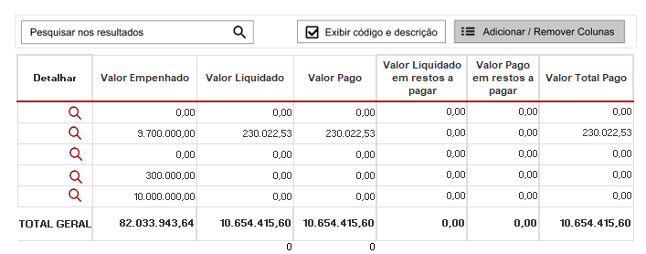

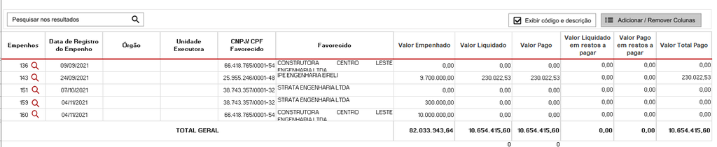

## BOTÕES DA TABELA MODAL

(inicio)

1- A tabela não está exibindo os botões de download, compartilhar, pesquisa e linhas;

2- Sugiro aumentar a largura da tabela

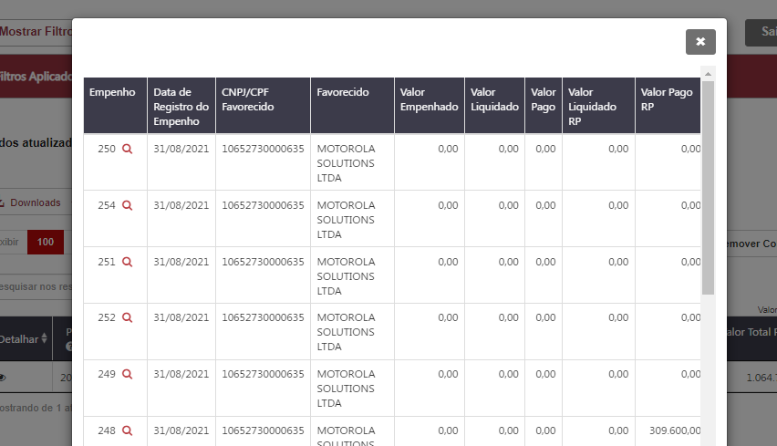

*Exceção:*  
Quando o usuário utilizar o filtro “*Número da Ordem de Pagamento*” na barra de filtro vertical as colunas abaixo deverão ser exibidas em formato desabilitado, sem a exibição de dados: - Valor empenhado - Valo liquidado - Valor liquidado em RP

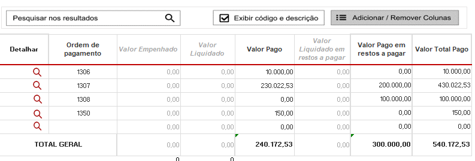

Caso o filtro "*Número da Ordem de Pagamento* seja retirado da barra de filtros aplicados a formatação e exibição dos valores dessas colunas seguirá o padrão.

4. Opção exportar Planilha (CSV): exibir código e descrição em colunas distintas, independente de o usuário selecionar a opção código na tabela de resultado. O período selecionado deverá ser exibido na primeira coluna da planilha;
5. A tabela de resultados deverá apresentar todos os atributos das tabelas da pesquisa básica.

## ORDEM DE PAGAMENTO

(inicio)

Não está funcionado. Comportamento descrito acima

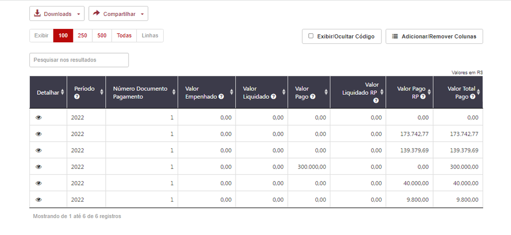

## CPF DESCARACTERIZADO

(inicio)

Todos os CPF devem ser descaracterizados conforme já ocorre em todas as consultas do PDT

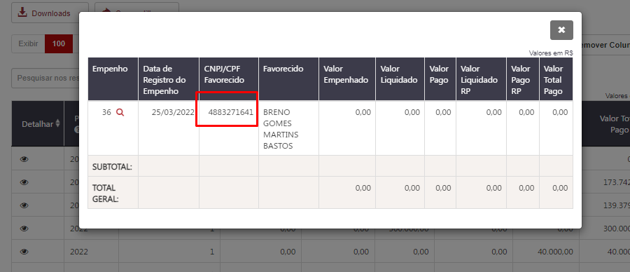